# **Regression Analysis: Sales Revenue Prediction**

# **Objective:**

SuperKart is an organization that owns a chain of supermarkets and food marts providing a wide range of products. They want to predict the future sales revenue of its different outlets so that they can strategize their sales operation across different tier cities and plan their inventory accordingly. To achieve this purpose, SuperKart has hired a data science firm, shared the sales records of its various outlets for the previous quarter, and asked the firm to come up with a suitable model to predict the total sales of the stores for the upcoming quarter.

# **Data Variables:**

The data contains the different attributes of the various products and stores. The detailed data dictionary is given below.

- Product_Id - unique identifier of each product, each identifier having two letters at the beginning followed by a number.
- Product_Weight - the weight of each product
- Product_Sugar_Content - sugar content of each product like low sugar, regular, and no sugar
- Product_Allocated_Area - the ratio of the allocated display area of each product to the total display area of all the products in a store
- Product_Type - broad category for each product like meat, snack foods, hard drinks, dairy, canned, soft drinks, health and hygiene, baking goods, bread, breakfast, frozen foods, fruits and vegetables, household, seafood, starchy foods, others
- Product_MRP - maximum retail price of each product
- Store_Id - unique identifier of each store
- Store_Establishment_Year - the year in which the store was established
- Store_Size - the size of the store depending on sq. feet like high, medium, and low
- Store_Location_City_Type - the type of city in which the store is located like Tier 1, Tier 2, and Tier 3. Tier 1 consists of cities where the standard of living is comparatively higher than its Tier 2 and Tier 3 counterparts.
- Store_Type - the type of store depending on the products that are being sold there like Departmental Store, Supermarket Type 1, Supermarket Type 2, and Food Mart
- Product_Store_Sales_Total - total revenue generated by the sale of that particular product in that particular store

# **Importing Libraries**

```python
# Libraries to help with reading and manipulating data
import numpy as np
import pandas as pd

# Library to split data
from sklearn.model_selection import train_test_split

# Libaries to help with data visualization
import matplotlib.pyplot as plt
import seaborn as sns

# Removes the limit for the number of displayed columns
pd.set_option("display.max_columns", None)
# Sets the limit for the number of displayed rows
pd.set_option("display.max_rows", 100)

# Import libraries for building linear regression model
from statsmodels.formula.api import ols
import statsmodels.api as sm
from sklearn.linear_model import LinearRegression

# Import library for preparing data
from sklearn.model_selection import train_test_split

import warnings
warnings.filterwarnings("ignore")
```

```python
#Importing SuperKart dataset

df = pd.read_csv('/content/SuperKart.csv')
```

```python
df.head()
```

|  | Product_Id | Product_Weight | Product_Sugar_Content | Product_Allocated_Area | Product_Type | Product_MRP | Store_Id | Store_Establishment_Year | Store_Size | Store_Location_City_Type | Store_Type | Product_Store_Sales_Total |
| --- | --- | --- | --- | --- | --- | --- | --- | --- | --- | --- | --- | --- |
| 0 | FD6114 | 12.66 | Low Sugar | 0.027 | Frozen Foods | 117.08 | OUT004 | 2009 | Medium | Tier 2 | Supermarket Type2 | 2842.40 |
| 1 | FD7839 | 16.54 | Low Sugar | 0.144 | Dairy | 171.43 | OUT003 | 1999 | Medium | Tier 1 | Departmental Store | 4830.02 |
| 2 | FD5075 | 14.28 | Regular | 0.031 | Canned | 162.08 | OUT001 | 1987 | High | Tier 2 | Supermarket Type1 | 4130.16 |
| 3 | FD8233 | 12.10 | Low Sugar | 0.112 | Baking Goods | 186.31 | OUT001 | 1987 | High | Tier 2 | Supermarket Type1 | 4132.18 |
| 4 | NC1180 | 9.57 | No Sugar | 0.010 | Health and Hygiene | 123.67 | OUT002 | 1998 | Small | Tier 3 | Food Mart | 2279.36 |

```python
#Undestanding the variables in the dataset

df.info()
```

```
<class 'pandas.core.frame.DataFrame'>
RangeIndex: 8763 entries, 0 to 8762
Data columns (total 12 columns):
 #   Column                     Non-Null Count  Dtype
---  ------                     --------------  -----
 0   Product_Id                 8763 non-null   object
 1   Product_Weight             8763 non-null   float64
 2   Product_Sugar_Content      8763 non-null   object
 3   Product_Allocated_Area     8763 non-null   float64
 4   Product_Type               8763 non-null   object
 5   Product_MRP                8763 non-null   float64
 6   Store_Id                   8763 non-null   object
 7   Store_Establishment_Year   8763 non-null   int64
 8   Store_Size                 8763 non-null   object
 9   Store_Location_City_Type   8763 non-null   object
 10  Store_Type                 8763 non-null   object
 11  Product_Store_Sales_Total  8763 non-null   float64
dtypes: float64(4), int64(1), object(7)
memory usage: 821.7+ KB
```

```python
#Checking for missing values

df.isnull().sum()
```

|  | 0 |
| --- | --- |
| Product_Id | 0 |
| Product_Weight | 0 |
| Product_Sugar_Content | 0 |
| Product_Allocated_Area | 0 |
| Product_Type | 0 |
| Product_MRP | 0 |
| Store_Id | 0 |
| Store_Establishment_Year | 0 |
| Store_Size | 0 |
| Store_Location_City_Type | 0 |
| Store_Type | 0 |
| Product_Store_Sales_Total | 0 |

**dtype:** int64

```python
#Checking for duplicate values

df.duplicated().sum()
```

```
np.int64(0)
```

# Observations:

The dataset is composed of 8763 rows and 12 columns, in which 7 of them are categorical variables and 5 are numerical variables. Our target variable, Product_Store_Sales_Total, is a continuous variable, and Regression Analysis will be performed to create prediction models to forecast Sales Revenue. The data do not contain missing values nor duplicate records.

# **Exploratory Data Analysis**

```python
#Checking the statistical summary of the data

df.describe().T
```

|  | count | mean | std | min | 25% | 50% | 75% | max |
| --- | --- | --- | --- | --- | --- | --- | --- | --- |
| Product_Weight | 8763.0 | 12.653792 | 2.217320 | 4.000 | 11.150 | 12.660 | 14.180 | 22.000 |
| Product_Allocated_Area | 8763.0 | 0.068786 | 0.048204 | 0.004 | 0.031 | 0.056 | 0.096 | 0.298 |
| Product_MRP | 8763.0 | 147.032539 | 30.694110 | 31.000 | 126.160 | 146.740 | 167.585 | 266.000 |
| Store_Establishment_Year | 8763.0 | 2002.032751 | 8.388381 | 1987.000 | 1998.000 | 2009.000 | 2009.000 | 2009.000 |
| Product_Store_Sales_Total | 8763.0 | 3464.003640 | 1065.630494 | 33.000 | 2761.715 | 3452.340 | 4145.165 | 8000.000 |

# Observations:

Product ID has 8763 unique values and because it contains ID information, it may not be interesting to keep in the analysis. Product weight varies from 4.0 to 22.0, but the unit is not explicitly described. Product_Allocated_Area refers to the ratio of the allocated display area of each product to the total display area of all the products in a store and this ratio ranges from 0.004 to 0.298. The oldest store was established in 1987 and the youngest in 2009. The Sales range from 33 to 8000 dollars.

```python
#Checking the different labels on each categorical variable

cat_cols = df.select_dtypes(include='object').columns

cat_cols = list(cat_cols)

cat_cols.remove('Product_Id')
cat_cols.remove('Store_Id')

cat_cols
```

```
['Product_Sugar_Content',
 'Product_Type',
 'Store_Size',
 'Store_Location_City_Type',
 'Store_Type']
```

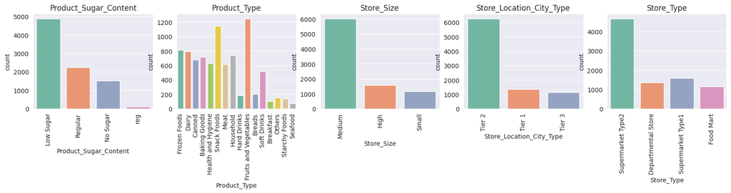

```python
plt.figure(figsize=(20, 16))

for i, variable in enumerate(cat_cols):
  sns.set_style('darkgrid')
  plt.subplot(5, 5, i+1)
  sns.countplot(data = df, x=df[variable], palette='Set2')
  plt.xticks(rotation=90)
  plt.title(variable)
plt.show()
```

# Observations:

The Product_Sugar_Content variable seems to contain different labels to the same purpose, so will adjust that. The most common product types are Snack Foods and Fruits and Vegetables. Most of the stores are od medium size, located at a Tier 2 city type and the dataset is composed mostly og Supermarket Type2 stores.

```python
# There are some issues with labels on Product_Sugar_Content, let's fix the issues

df['Product_Sugar_Content'] = df['Product_Sugar_Content'].apply(lambda x: 'Regular' if x == 'reg' else x)
```

```python
df.Product_Sugar_Content.value_counts()
```

| Product_Sugar_Content | count |
| --- | --- |
| Low Sugar | 4885 |
| Regular | 2359 |
| No Sugar | 1519 |

**dtype:** int64

```python
#Checking the Product ID Variable

df['Product_Id'].str[:2].value_counts()
```

| Product_Id | count |
| --- | --- |
| FD | 6539 |
| NC | 1519 |
| DR | 705 |

**dtype:** int64

Observartions: Although the Product ID is unique for each product, it seems that there is a pattern on each ID.

```python
# Extracting the first two characters from the Product_Id column and storing it in another column
df["Product_Id_char"] = df["Product_Id"].str[:2]

df.head()
```

|  | Product_Id | Product_Weight | Product_Sugar_Content | Product_Allocated_Area | Product_Type | Product_MRP | Store_Id | Store_Establishment_Year | Store_Size | Store_Location_City_Type | Store_Type | Product_Store_Sales_Total | Product_Id_char |
| --- | --- | --- | --- | --- | --- | --- | --- | --- | --- | --- | --- | --- | --- |
| 0 | FD6114 | 12.66 | Low Sugar | 0.027 | Frozen Foods | 117.08 | OUT004 | 2009 | Medium | Tier 2 | Supermarket Type2 | 2842.40 | FD |
| 1 | FD7839 | 16.54 | Low Sugar | 0.144 | Dairy | 171.43 | OUT003 | 1999 | Medium | Tier 1 | Departmental Store | 4830.02 | FD |
| 2 | FD5075 | 14.28 | Regular | 0.031 | Canned | 162.08 | OUT001 | 1987 | High | Tier 2 | Supermarket Type1 | 4130.16 | FD |
| 3 | FD8233 | 12.10 | Low Sugar | 0.112 | Baking Goods | 186.31 | OUT001 | 1987 | High | Tier 2 | Supermarket Type1 | 4132.18 | FD |
| 4 | NC1180 | 9.57 | No Sugar | 0.010 | Health and Hygiene | 123.67 | OUT002 | 1998 | Small | Tier 3 | Food Mart | 2279.36 | NC |

```python
#Checking all the product types that composes the new label FD

df.loc[df.Product_Id_char == "FD", "Product_Type"].unique()
```

```
array(['Frozen Foods', 'Dairy', 'Canned', 'Baking Goods', 'Snack Foods',
       'Meat', 'Fruits and Vegetables', 'Breads', 'Breakfast',
       'Starchy Foods', 'Seafood'], dtype=object)
```

```python
#Checking all the product types that composes the new label NC

df.loc[df.Product_Id_char == "NC", "Product_Type"].unique()
```

```
array(['Health and Hygiene', 'Household', 'Others'], dtype=object)
```

```python
#Checking all the product types that composes the new label DR

df.loc[df.Product_Id_char == "DR", "Product_Type"].unique()
```

```
array(['Hard Drinks', 'Soft Drinks'], dtype=object)
```

```python
#Dropping the Product_Id column:

df = df.drop(['Product_Id'], axis=1)
```

```python
df.head()
```

|  | Product_Weight | Product_Sugar_Content | Product_Allocated_Area | Product_Type | Product_MRP | Store_Id | Store_Establishment_Year | Store_Size | Store_Location_City_Type | Store_Type | Product_Store_Sales_Total | Product_Id_char |
| --- | --- | --- | --- | --- | --- | --- | --- | --- | --- | --- | --- | --- |
| 0 | 12.66 | Low Sugar | 0.027 | Frozen Foods | 117.08 | OUT004 | 2009 | Medium | Tier 2 | Supermarket Type2 | 2842.40 | FD |
| 1 | 16.54 | Low Sugar | 0.144 | Dairy | 171.43 | OUT003 | 1999 | Medium | Tier 1 | Departmental Store | 4830.02 | FD |
| 2 | 14.28 | Regular | 0.031 | Canned | 162.08 | OUT001 | 1987 | High | Tier 2 | Supermarket Type1 | 4130.16 | FD |
| 3 | 12.10 | Low Sugar | 0.112 | Baking Goods | 186.31 | OUT001 | 1987 | High | Tier 2 | Supermarket Type1 | 4132.18 | FD |
| 4 | 9.57 | No Sugar | 0.010 | Health and Hygiene | 123.67 | OUT002 | 1998 | Small | Tier 3 | Food Mart | 2279.36 | NC |

# Observations:

We can see that the FD products refer to food products, while NC refers to household, hygiene and other products; and DR refers to drinks.

# **Univariate Analysis**

```python
#Creating Histograms for all numerical variables in the dataset

num_cols = list(df.select_dtypes(include=['int64', 'float64']).columns)

num_cols
```

```
['Product_Weight',
 'Product_Allocated_Area',
 'Product_MRP',
 'Store_Establishment_Year',
 'Product_Store_Sales_Total']
```

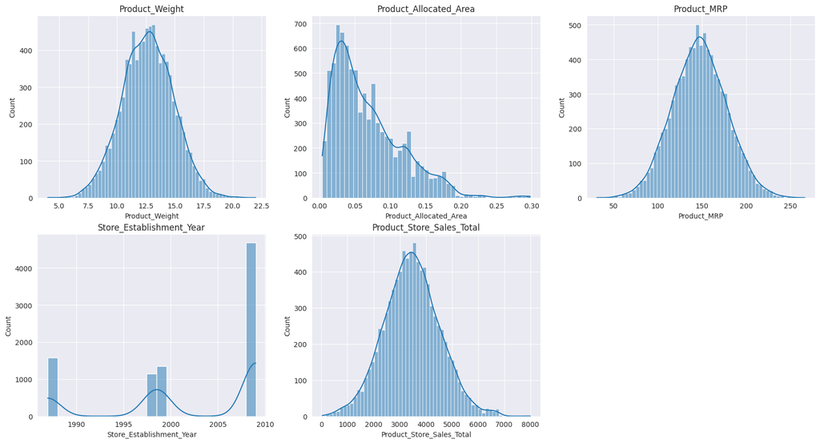

```python
plt.figure(figsize=(20, 16))

for i, variable in enumerate(num_cols):
  sns.set_style('darkgrid')
  plt.subplot(3, 3, i+1)
  sns.histplot(data = df, x= variable, kde=True)
  plt.xlabel(variable)
  plt.title(variable)
plt.show()
```

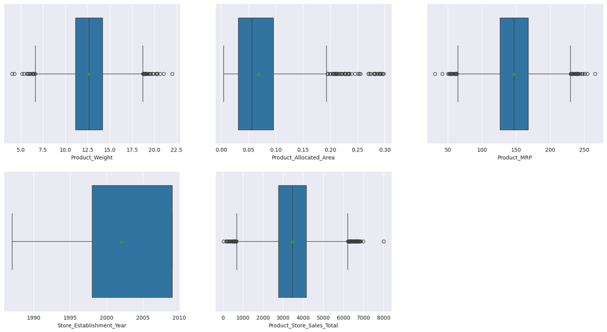

```python
plt.figure(figsize=(20, 16))

for i, variable in enumerate(num_cols):
  sns.set_style('darkgrid')
  plt.subplot(3, 3, i+1)
  sns.boxplot(data=df, x=variable, showmeans=True)
  plt.xlabel(variable)
plt.show()
```

# Observations:

Product Weight and Product MRP, and the target variable Product Sales appear to be normally distributed, with a median of 12.5, 150, and 3500, respectively. Product allocated area is right skewed, an 75% of the ratio of the allocated display area of each product is less than 0.10.

```python
import matplotlib.pyplot as plt
import seaborn as sns

def labeled_barplot(df, feature, perc=False, n=None):
    """
    Horizontal barplot with count or percentage labels at the end of each bar.

    df: dataframe
    feature: dataframe column
    perc: whether to display percentages instead of counts (default False)
    n: display top n categories (default all)
    """

    total = len(df[feature])  # total rows
    order = df[feature].value_counts().index[:n]  # order by frequency

    plt.figure(figsize=(8, max(5, len(order) * 0.5)))  # dynamic height
    ax = sns.countplot(
        data=df,
        y=feature,
        order=order,
        palette="Set2"
    )

    for p in ax.patches:
        if perc:
            label = "{:.1f}%".format(100 * p.get_width() / total)
        else:
            label = p.get_width()

        x = p.get_width()   # bar length
        y = p.get_y() + p.get_height() / 2  # bar center

        ax.annotate(
            label,
            (x, y),
            ha="left",  # place label to the right
            va="center",
            size=12,
            xytext=(5, 0),  # offset a little to the right
            textcoords="offset points"
        )

    plt.xlabel("Count" if not perc else "Percentage")
    plt.ylabel(feature)
    plt.show()
```

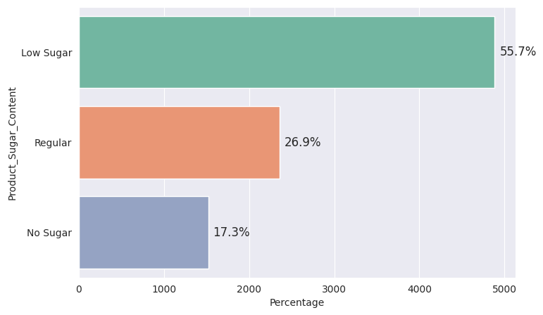

```python
#Product Sugar Content Barplot

labeled_barplot(df, "Product_Sugar_Content", perc = True)
```

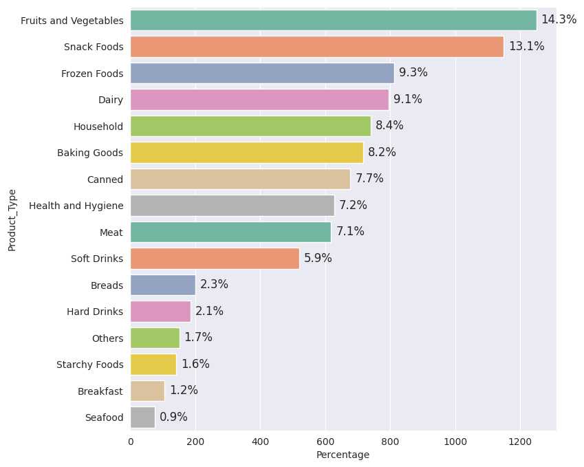

```python
#Product Type Barplot

labeled_barplot(df, "Product_Type", perc = True)
```

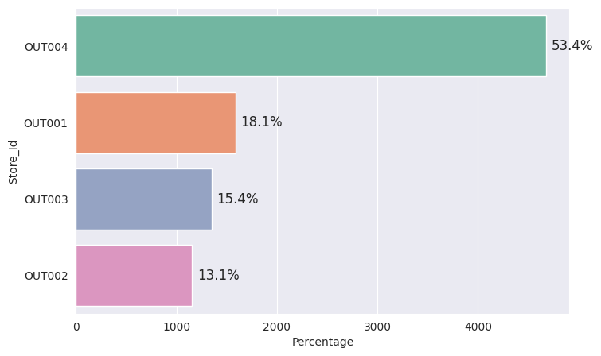

```python
#Store Id Barplot

labeled_barplot(df, "Store_Id", perc = True)
```

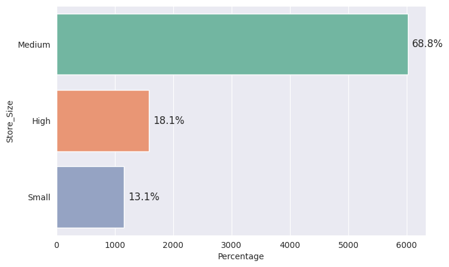

```python
#Store Size Barplot

labeled_barplot(df, "Store_Size", perc = True)
```

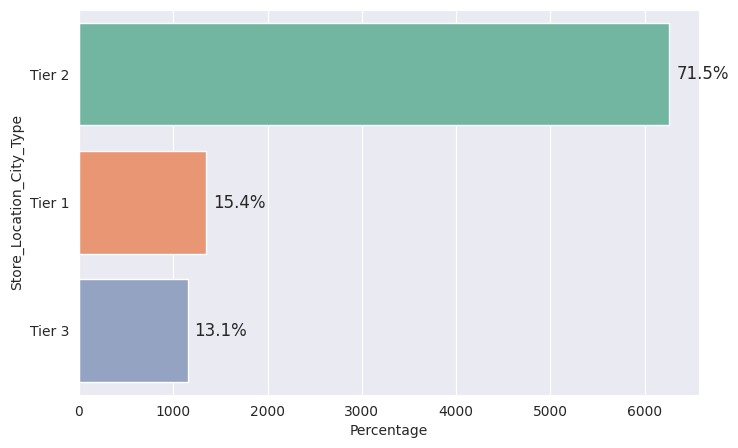

```python
#Store Location City Type Barplot

labeled_barplot(df, "Store_Location_City_Type", perc = True)
```

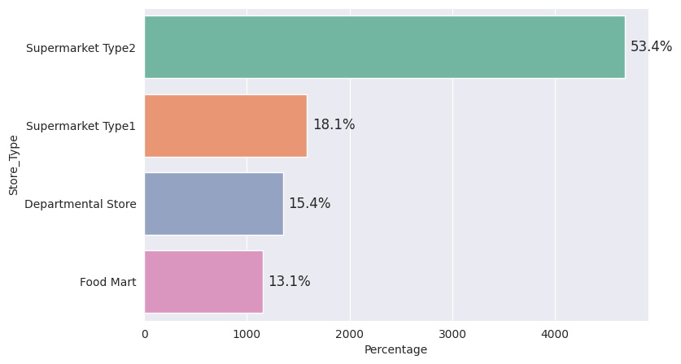

```python
#Store Type Barplot

labeled_barplot(df, "Store_Type", perc = True)
```

# Observations:

The barplots highlight several notable patterns in the categorical variables.

# **Bivariate Analysis**

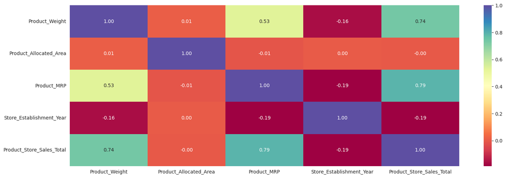

```python
#Creating a correlation matrix

plt.figure(figsize=(18, 6))

sns.heatmap(df.corr(numeric_only=True), annot=True, fmt = ".2f", cmap = "Spectral")
plt.show()
```

# Observations:

- Both Product Weight and Product MRP show a positive correlation with the target variable (Product Sales Total), indicating that heavier and higher-priced products tend to generate higher sales.
- Product Weight and Product MRP appear correlated with each other. This suggests the need to formally test for multicollinearity in subsequent modeling steps, as it may affect the stability of regression coefficients.

```python
#Creating Bi_variate Scatter plots with the target variable:


num_cols2 = num_cols.copy()
num_cols2.remove('Product_Store_Sales_Total')
num_cols2.remove('Store_Establishment_Year')

num_cols2
```

```
['Product_Weight', 'Product_Allocated_Area', 'Product_MRP']
```

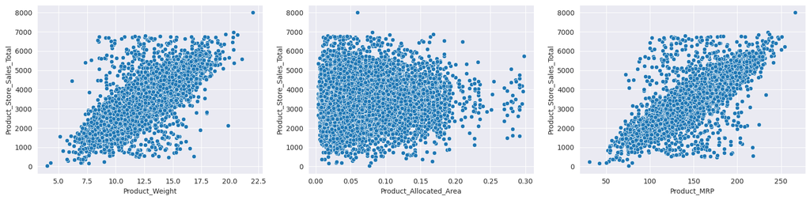

```python
plt.figure(figsize=(20, 15))

for i, variable in enumerate(num_cols2):
  sns.set_style('darkgrid')
  plt.subplot(3, 3, i+1)
  sns.scatterplot(data = df, x= variable, y='Product_Store_Sales_Total')
  plt.xlabel(variable)
plt.show()
```

# Observations:

- From the scatterplots above, it seems there is a linear relationship between Product Weight and Product MRP and the target variable.
- There is no clear relationship between the target variable and Product Allocated Area.

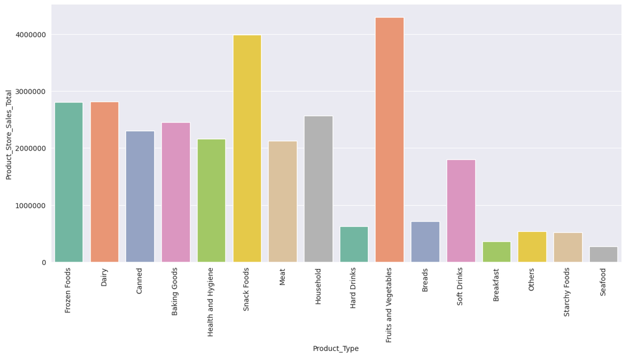

```
Total Revenue: 30355063.9
```

```python
#Checking the product type the company is generating most of the revenue

import matplotlib.ticker as ticker

plt.figure(figsize=(20, 15))

g = sns.catplot(data=df,
            x="Product_Type",
            y="Product_Store_Sales_Total",
            hue="Product_Type",
            kind='bar',
            palette='Set2',
            estimator=np.sum,
            ci=None,
            height=6,
            aspect=2)

ax=g.ax

ax.ticklabel_format(style='plain', axis='y')

plt.xticks(rotation=90)

plt.show()

print('Total Revenue:', df['Product_Store_Sales_Total'].sum())
```

# Observations:

Fruits and Vegetables and Snack Foods together represent 26% of the total revenue, while frozen foods and dairy contribute to almost 19% of the total revenue. We can see that breakfast and starchy foods and seafood are the smallest contributors to total revenue.

```python
cat_cols2 = cat_cols.copy()
cat_cols2.remove('Product_Type')

cat_cols2
```

```
['Product_Sugar_Content',
 'Store_Size',
 'Store_Location_City_Type',
 'Store_Type']
```

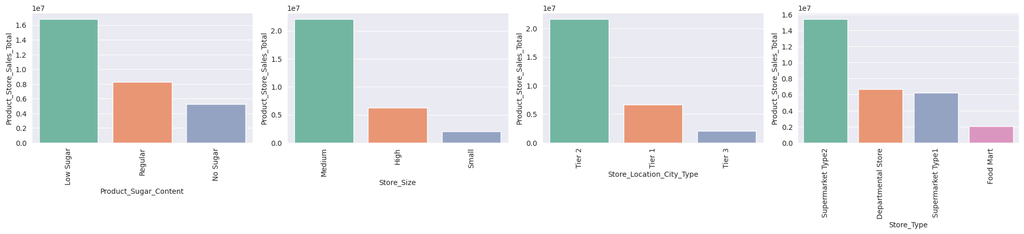

```python
plt.figure(figsize=(20, 16))

for i, variable in enumerate(cat_cols2):
    sns.set_style('darkgrid')
    plt.subplot(4, 4, i+1)  # 3x3 grid
    ax = sns.barplot(
        data=df,
        x=variable,
        y="Product_Store_Sales_Total",
        hue=variable,
        estimator=np.sum,
        ci=None,
        palette="Set2"
    )
    plt.xlabel(variable)
    plt.xticks(rotation=90)

plt.tight_layout()
plt.show()
```

# Observations:

It is possible to see from the categorical variables above that the greatest drivers for the total revenue are Low Sugar Products, products sold at Medium sized stores and Tier 2 city types as well as Supermarket Type2 store types.

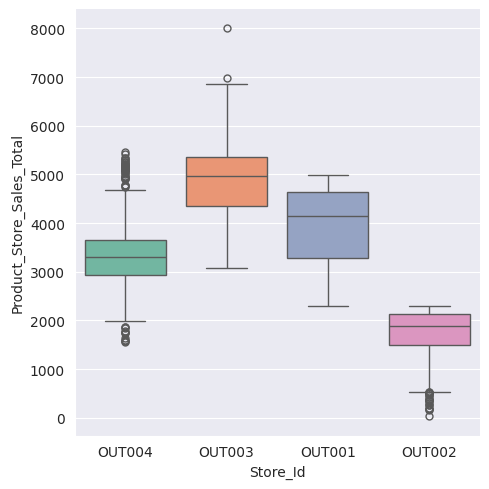

```python
#checking the distribution of our target variable with the other categorical columns

sns.catplot(data=df, x="Store_Id", y="Product_Store_Sales_Total", hue="Store_Id", kind='box', palette='Set2');
```

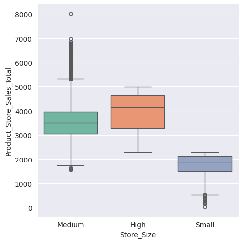

```python
# Plot the boxplot of Store size against Product_Store_Sales_Total

sns.catplot(data=df, x="Store_Size", y="Product_Store_Sales_Total", hue="Store_Size", kind='box', palette='Set2');
```

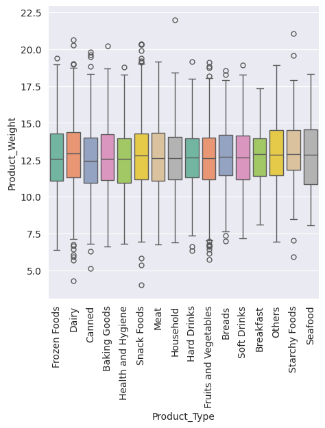

```python
# Plot the boxplot of Product_Type against Product_Weight

sns.catplot(data=df, x="Product_Type", y="Product_Weight", hue="Product_Type", kind='box', palette='Set2')
plt.xticks(rotation=90);
```

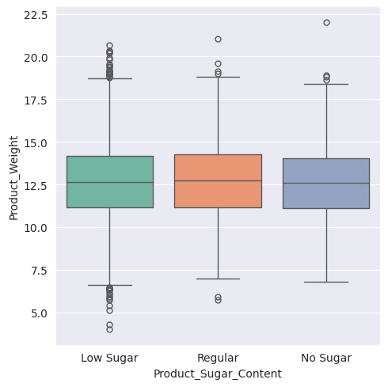

```python
# Plot the box plot of Product_Sugar_Content against Product_Weight

sns.catplot(data=df, x="Product_Sugar_Content", y="Product_Weight", hue="Product_Sugar_Content", kind='box', palette='Set2')
plt.show()
```

# Observations:

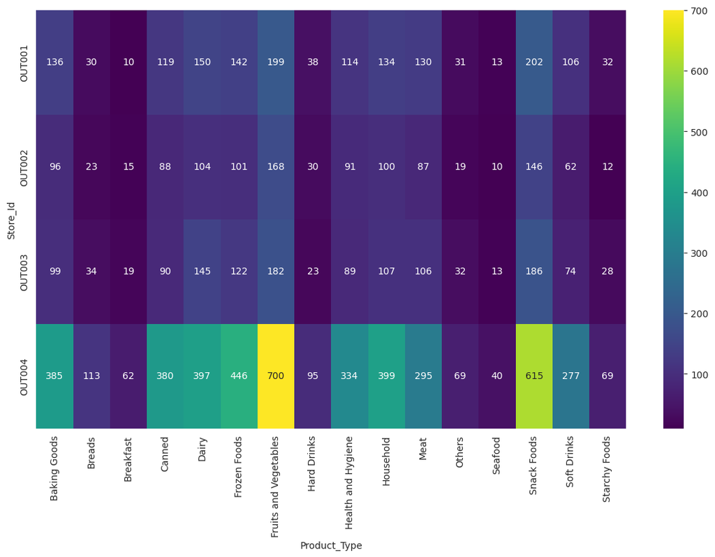

```python
# Checking how many items of each product type has been sold in each of the stores

plt.figure(figsize = (14, 8))

sns.heatmap(
    pd.crosstab(df["Store_Id"], df["Product_Type"]),
    annot=True,
    fmt = "g",
    cmap = "viridis",
)

plt.show()
```

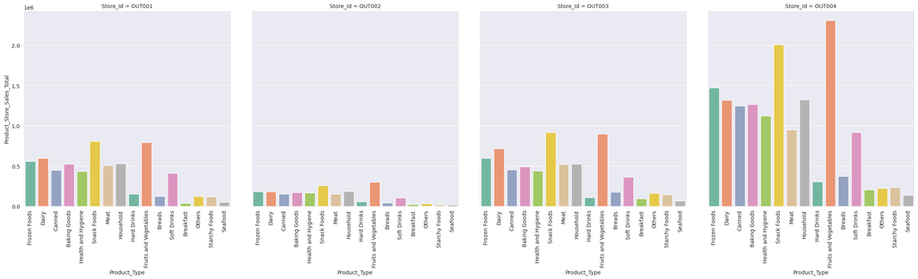

```python
#Verifying total revenue by product type per Store ID

g = sns.catplot(
    data=df,
    x="Product_Type",
    y="Product_Store_Sales_Total",
    col="Store_Id",
    kind='bar',
    palette='Set2',
    estimator=np.sum,
    ci=None,
    col_order=["OUT001", "OUT002", "OUT003", "OUT004"],
    height=6,
    aspect=1
)

g.set_xticklabels(rotation=90)
plt.show()
```

# OUT001:

```python
df.loc[df["Store_Id"] == "OUT001"].describe(include = "all").T
```

|  | count | unique | top | freq | mean | std | min | 25% | 50% | 75% | max |
| --- | --- | --- | --- | --- | --- | --- | --- | --- | --- | --- | --- |
| Product_Weight | 1586.0 | NaN | NaN | NaN | 13.458865 | 2.064975 | 6.16 | 12.0525 | 13.96 | 14.95 | 17.97 |
| Product_Sugar_Content | 1586 | 3 | Low Sugar | 845 | NaN | NaN | NaN | NaN | NaN | NaN | NaN |
| Product_Allocated_Area | 1586.0 | NaN | NaN | NaN | 0.068768 | 0.047131 | 0.004 | 0.033 | 0.0565 | 0.094 | 0.295 |
| Product_Type | 1586 | 16 | Snack Foods | 202 | NaN | NaN | NaN | NaN | NaN | NaN | NaN |
| Product_MRP | 1586.0 | NaN | NaN | NaN | 160.514054 | 30.359059 | 71.35 | 141.72 | 168.32 | 182.9375 | 226.59 |
| Store_Id | 1586 | 1 | OUT001 | 1586 | NaN | NaN | NaN | NaN | NaN | NaN | NaN |
| Store_Establishment_Year | 1586.0 | NaN | NaN | NaN | 1987.0 | 0.0 | 1987.0 | 1987.0 | 1987.0 | 1987.0 | 1987.0 |
| Store_Size | 1586 | 1 | High | 1586 | NaN | NaN | NaN | NaN | NaN | NaN | NaN |
| Store_Location_City_Type | 1586 | 1 | Tier 2 | 1586 | NaN | NaN | NaN | NaN | NaN | NaN | NaN |
| Store_Type | 1586 | 1 | Supermarket Type1 | 1586 | NaN | NaN | NaN | NaN | NaN | NaN | NaN |
| Product_Store_Sales_Total | 1586.0 | NaN | NaN | NaN | 3923.778802 | 904.62901 | 2300.56 | 3285.51 | 4139.645 | 4639.4 | 4997.63 |
| Product_Id_char | 1586 | 3 | FD | 1163 | NaN | NaN | NaN | NaN | NaN | NaN | NaN |

```python
df.loc[df["Store_Id"] == "OUT001", "Product_Store_Sales_Total"].sum()
```

```
np.float64(6223113.18)
```

- Store Profile: OUT001 is a Supermarket Type 1 outlet, located in a Tier 2 city, classified as a large-sized store, and established in 1987.
- Product Pricing: The MRP of products sold at this store ranges between 71 and 227.
- Sales Volume: Snack Foods represent the most frequently purchased category at OUT001.
- Revenue Range: Individual product revenues at this store vary between 2,300 and 5,000.
- Total Revenue: OUT001 has generated a total revenue of approximately 6.22 million, with the leading contributors being Fruits and Vegetables, Snack Foods, and Dairy.

# OUT002:

```python
df.loc[df["Store_Id"] == "OUT002"].describe(include = "all").T
```

|  | count | unique | top | freq | mean | std | min | 25% | 50% | 75% | max |
| --- | --- | --- | --- | --- | --- | --- | --- | --- | --- | --- | --- |
| Product_Weight | 1152.0 | NaN | NaN | NaN | 9.911241 | 1.799846 | 4.0 | 8.7675 | 9.795 | 10.89 | 19.82 |
| Product_Sugar_Content | 1152 | 3 | Low Sugar | 658 | NaN | NaN | NaN | NaN | NaN | NaN | NaN |
| Product_Allocated_Area | 1152.0 | NaN | NaN | NaN | 0.067747 | 0.047567 | 0.006 | 0.031 | 0.0545 | 0.09525 | 0.292 |
| Product_Type | 1152 | 16 | Fruits and Vegetables | 168 | NaN | NaN | NaN | NaN | NaN | NaN | NaN |
| Product_MRP | 1152.0 | NaN | NaN | NaN | 107.080634 | 24.912333 | 31.0 | 92.8275 | 104.675 | 117.8175 | 224.93 |
| Store_Id | 1152 | 1 | OUT002 | 1152 | NaN | NaN | NaN | NaN | NaN | NaN | NaN |
| Store_Establishment_Year | 1152.0 | NaN | NaN | NaN | 1998.0 | 0.0 | 1998.0 | 1998.0 | 1998.0 | 1998.0 | 1998.0 |
| Store_Size | 1152 | 1 | Small | 1152 | NaN | NaN | NaN | NaN | NaN | NaN | NaN |
| Store_Location_City_Type | 1152 | 1 | Tier 3 | 1152 | NaN | NaN | NaN | NaN | NaN | NaN | NaN |
| Store_Type | 1152 | 1 | Food Mart | 1152 | NaN | NaN | NaN | NaN | NaN | NaN | NaN |
| Product_Store_Sales_Total | 1152.0 | NaN | NaN | NaN | 1762.942465 | 462.862431 | 33.0 | 1495.4725 | 1889.495 | 2133.6225 | 2299.63 |
| Product_Id_char | 1152 | 3 | FD | 850 | NaN | NaN | NaN | NaN | NaN | NaN | NaN |

```python
df.loc[df["Store_Id"] == "OUT002", "Product_Store_Sales_Total"].sum()
```

```
np.float64(2030909.72)
```

# OUT003:

```python
df.loc[df["Store_Id"] == "OUT003"].describe(include = "all").T
```

|  | count | unique | top | freq | mean | std | min | 25% | 50% | 75% | max |
| --- | --- | --- | --- | --- | --- | --- | --- | --- | --- | --- | --- |
| Product_Weight | 1349.0 | NaN | NaN | NaN | 15.103692 | 1.893531 | 7.35 | 14.02 | 15.18 | 16.35 | 22.0 |
| Product_Sugar_Content | 1349 | 3 | Low Sugar | 750 | NaN | NaN | NaN | NaN | NaN | NaN | NaN |
| Product_Allocated_Area | 1349.0 | NaN | NaN | NaN | 0.068637 | 0.048708 | 0.004 | 0.031 | 0.057 | 0.094 | 0.298 |
| Product_Type | 1349 | 16 | Snack Foods | 186 | NaN | NaN | NaN | NaN | NaN | NaN | NaN |
| Product_MRP | 1349.0 | NaN | NaN | NaN | 181.358725 | 24.796429 | 85.88 | 166.92 | 179.67 | 198.07 | 266.0 |
| Store_Id | 1349 | 1 | OUT003 | 1349 | NaN | NaN | NaN | NaN | NaN | NaN | NaN |
| Store_Establishment_Year | 1349.0 | NaN | NaN | NaN | 1999.0 | 0.0 | 1999.0 | 1999.0 | 1999.0 | 1999.0 | 1999.0 |
| Store_Size | 1349 | 1 | Medium | 1349 | NaN | NaN | NaN | NaN | NaN | NaN | NaN |
| Store_Location_City_Type | 1349 | 1 | Tier 1 | 1349 | NaN | NaN | NaN | NaN | NaN | NaN | NaN |
| Store_Type | 1349 | 1 | Departmental Store | 1349 | NaN | NaN | NaN | NaN | NaN | NaN | NaN |
| Product_Store_Sales_Total | 1349.0 | NaN | NaN | NaN | 4946.966323 | 677.539953 | 3069.24 | 4355.39 | 4958.29 | 5366.59 | 8000.0 |
| Product_Id_char | 1349 | 3 | FD | 1024 | NaN | NaN | NaN | NaN | NaN | NaN | NaN |

```python
df.loc[df["Store_Id"] == "OUT003", "Product_Store_Sales_Total"].sum()
```

```
np.float64(6673457.57)
```

# OUT004:

```python
df.loc[df["Store_Id"] == "OUT004"].describe(include = "all").T
```

|  | count | unique | top | freq | mean | std | min | 25% | 50% | 75% | max |
| --- | --- | --- | --- | --- | --- | --- | --- | --- | --- | --- | --- |
| Product_Weight | 4676.0 | NaN | NaN | NaN | 12.349613 | 1.428199 | 7.34 | 11.37 | 12.37 | 13.3025 | 17.79 |
| Product_Sugar_Content | 4676 | 3 | Low Sugar | 2632 | NaN | NaN | NaN | NaN | NaN | NaN | NaN |
| Product_Allocated_Area | 4676.0 | NaN | NaN | NaN | 0.069092 | 0.048584 | 0.004 | 0.031 | 0.056 | 0.097 | 0.297 |
| Product_Type | 4676 | 16 | Fruits and Vegetables | 700 | NaN | NaN | NaN | NaN | NaN | NaN | NaN |
| Product_MRP | 4676.0 | NaN | NaN | NaN | 142.399709 | 17.513973 | 83.04 | 130.54 | 142.82 | 154.1925 | 197.66 |
| Store_Id | 4676 | 1 | OUT004 | 4676 | NaN | NaN | NaN | NaN | NaN | NaN | NaN |
| Store_Establishment_Year | 4676.0 | NaN | NaN | NaN | 2009.0 | 0.0 | 2009.0 | 2009.0 | 2009.0 | 2009.0 | 2009.0 |
| Store_Size | 4676 | 1 | Medium | 4676 | NaN | NaN | NaN | NaN | NaN | NaN | NaN |
| Store_Location_City_Type | 4676 | 1 | Tier 2 | 4676 | NaN | NaN | NaN | NaN | NaN | NaN | NaN |
| Store_Type | 4676 | 1 | Supermarket Type2 | 4676 | NaN | NaN | NaN | NaN | NaN | NaN | NaN |
| Product_Store_Sales_Total | 4676.0 | NaN | NaN | NaN | 3299.312111 | 468.271692 | 1561.06 | 2942.085 | 3304.18 | 3646.9075 | 5462.86 |
| Product_Id_char | 4676 | 3 | FD | 3502 | NaN | NaN | NaN | NaN | NaN | NaN | NaN |

```python
df.loc[df["Store_Id"] == "OUT004", "Product_Store_Sales_Total"].sum()
```

```
np.float64(15427583.43)
```

- Store Profile: OUT004 is a Supermarket Type2, located in a Tier 2 city, classified as a medium-sized store, and established in 2009.
- Product Pricing: The MRP of products sold at this store ranges between 83 and 198.
- Sales Volume: Fruits and Vegetables represent the most frequently purchased category at OUT004.
- Revenue Range: Individual product revenues at this store vary between 1,560 and 5,460.
- Total Revenue: OUT004 has generated a total revenue of approximately 15.43 million, with the leading contributors being Snack Foods, Fruits and Vegetables and Frozen foods.

# **Feature Engineering**

```python
#Creating a Store Age Variable based on the establishment year and the data collection year (2021)

df['Store_Age'] = 2021 - df['Store_Establishment_Year']
```

```python
df['Product_Category'] = df['Product_Type'].apply(lambda x: 'Perishables'
                                                  if x == 'Dairy'
                                                  or x == 'Meat'
                                                  or x == 'Fruits and Vegetables'
                                                  or x == 'Breakfast'
                                                  or x == 'Breads'
                                                  or x == 'Seafood'
                                                  else 'Non Perishables')
```

```python
df.head()
```

|  | Product_Weight | Product_Sugar_Content | Product_Allocated_Area | Product_Type | Product_MRP | Store_Id | Store_Establishment_Year | Store_Size | Store_Location_City_Type | Store_Type | Product_Store_Sales_Total | Product_Id_char | Store_Age | Product_Category |
| --- | --- | --- | --- | --- | --- | --- | --- | --- | --- | --- | --- | --- | --- | --- |
| 0 | 12.66 | Low Sugar | 0.027 | Frozen Foods | 117.08 | OUT004 | 2009 | Medium | Tier 2 | Supermarket Type2 | 2842.40 | FD | 12 | Non Perishables |
| 1 | 16.54 | Low Sugar | 0.144 | Dairy | 171.43 | OUT003 | 1999 | Medium | Tier 1 | Departmental Store | 4830.02 | FD | 22 | Perishables |
| 2 | 14.28 | Regular | 0.031 | Canned | 162.08 | OUT001 | 1987 | High | Tier 2 | Supermarket Type1 | 4130.16 | FD | 34 | Non Perishables |
| 3 | 12.10 | Low Sugar | 0.112 | Baking Goods | 186.31 | OUT001 | 1987 | High | Tier 2 | Supermarket Type1 | 4132.18 | FD | 34 | Non Perishables |
| 4 | 9.57 | No Sugar | 0.010 | Health and Hygiene | 123.67 | OUT002 | 1998 | Small | Tier 3 | Food Mart | 2279.36 | NC | 23 | Non Perishables |

```python
df.value_counts('Product_Category')
```

| Product_Category | count |
| --- | --- |
| Non Perishables | 5718 |
| Perishables | 3045 |

**dtype:** int64

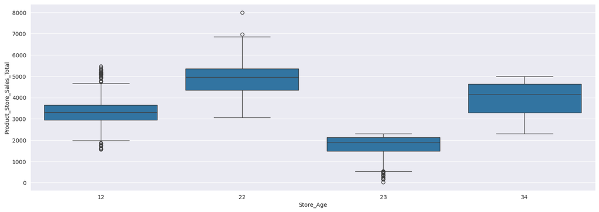

```python
#Creating boxplots for the different store ages against sales:

plt.figure(figsize=(18, 6))
sns.boxplot(data=df, x='Store_Age', y='Product_Store_Sales_Total')
```

- It is not possible to infer from the boxplots above that as the store gets older, the sales increase.

# **Modeling**

```python
# Removing "Product_Type", "Store_Id", "Store_Establishment_Year" variables from the data

df = df.drop(['Product_Type', 'Store_Id', 'Store_Establishment_Year'], axis=1)
```

```python
df.info()
```

```
<class 'pandas.core.frame.DataFrame'>
RangeIndex: 8763 entries, 0 to 8762
Data columns (total 11 columns):
 #   Column                     Non-Null Count  Dtype
---  ------                     --------------  -----
 0   Product_Weight             8763 non-null   float64
 1   Product_Sugar_Content      8763 non-null   object
 2   Product_Allocated_Area     8763 non-null   float64
 3   Product_MRP                8763 non-null   float64
 4   Store_Size                 8763 non-null   object
 5   Store_Location_City_Type   8763 non-null   object
 6   Store_Type                 8763 non-null   object
 7   Product_Store_Sales_Total  8763 non-null   float64
 8   Product_Id_char            8763 non-null   object
 9   Store_Age                  8763 non-null   int64
 10  Product_Category           8763 non-null   object
dtypes: float64(4), int64(1), object(6)
memory usage: 753.2+ KB
```

```python
#Lets create dummy variables for the categorical variables (one hot encoded representation)

df_dummy = pd.get_dummies(df, drop_first=True)
```

```python
df_dummy.info()
```

```
<class 'pandas.core.frame.DataFrame'>
RangeIndex: 8763 entries, 0 to 8762
Data columns (total 17 columns):
 #   Column                           Non-Null Count  Dtype
---  ------                           --------------  -----
 0   Product_Weight                   8763 non-null   float64
 1   Product_Allocated_Area           8763 non-null   float64
 2   Product_MRP                      8763 non-null   float64
 3   Product_Store_Sales_Total        8763 non-null   float64
 4   Store_Age                        8763 non-null   int64
 5   Product_Sugar_Content_No Sugar   8763 non-null   bool
 6   Product_Sugar_Content_Regular    8763 non-null   bool
 7   Store_Size_Medium                8763 non-null   bool
 8   Store_Size_Small                 8763 non-null   bool
 9   Store_Location_City_Type_Tier 2  8763 non-null   bool
 10  Store_Location_City_Type_Tier 3  8763 non-null   bool
 11  Store_Type_Food Mart             8763 non-null   bool
 12  Store_Type_Supermarket Type1     8763 non-null   bool
 13  Store_Type_Supermarket Type2     8763 non-null   bool
 14  Product_Id_char_FD               8763 non-null   bool
 15  Product_Id_char_NC               8763 non-null   bool
 16  Product_Category_Perishables     8763 non-null   bool
dtypes: bool(12), float64(4), int64(1)
memory usage: 445.1 KB
```

```python
# Separating features and the target column

X = df_dummy.drop(['Product_Store_Sales_Total'], axis=1)
y = df_dummy['Product_Store_Sales_Total']
```

```python
#X = sm.add_constant(X)
```

```python
# Splitting the data into train and test sets in 70:30 ratio

X_train, X_test, y_train, y_test = train_test_split(X, y, test_size=0.3, random_state=42)
```

```python
X_train.shape, X_test.shape
```

```
((6134, 16), (2629, 16))
```

```python
X_train.head()
```

|  | Product_Weight | Product_Allocated_Area | Product_MRP | Store_Age | Product_Sugar_Content_No Sugar | Product_Sugar_Content_Regular | Store_Size_Medium | Store_Size_Small | Store_Location_City_Type_Tier 2 | Store_Location_City_Type_Tier 3 | Store_Type_Food Mart | Store_Type_Supermarket Type1 | Store_Type_Supermarket Type2 | Product_Id_char_FD | Product_Id_char_NC | Product_Category_Perishables |
| --- | --- | --- | --- | --- | --- | --- | --- | --- | --- | --- | --- | --- | --- | --- | --- | --- |
| 2963 | 11.09 | 0.158 | 153.24 | 12 | False | False | True | False | True | False | False | False | True | False | False | False |
| 599 | 11.72 | 0.057 | 155.53 | 12 | False | False | True | False | True | False | False | False | True | True | False | True |
| 45 | 12.00 | 0.097 | 157.77 | 12 | False | False | True | False | True | False | False | False | True | True | False | False |
| 1444 | 14.51 | 0.090 | 189.42 | 34 | False | True | False | False | True | False | False | True | False | True | False | False |
| 1652 | 11.58 | 0.090 | 123.81 | 12 | True | False | True | False | True | False | False | False | True | False | True | False |

```python
#Importing libraries for scaling the data
from sklearn.preprocessing import MinMaxScaler
```

```python
#Scaling numerical variables to have the same range

scaler = MinMaxScaler()
```

```python
#Applying fit_transform on the training features data

X_train_scaled = scaler.fit_transform(X_train)
X_train_scaled
```

```
array([[0.39388889, 0.52559727, 0.52017021, ..., 0.        , 0.        ,
        0.        ],
       [0.42888889, 0.18088737, 0.52991489, ..., 1.        , 0.        ,
        1.        ],
       [0.44444444, 0.31740614, 0.53944681, ..., 1.        , 0.        ,
        0.        ],
       ...,
       [0.47777778, 0.0887372 , 0.47480851, ..., 1.        , 0.        ,
        1.        ],
       [0.38333333, 0.21501706, 0.62731915, ..., 0.        , 1.        ,
        0.        ],
       [0.50611111, 0.63822526, 0.54621277, ..., 1.        , 0.        ,
        0.        ]])
```

```python
#The above scaler returns data in array format, so lets convert ir back to pd.DataFrame

X_train_scaled = pd.DataFrame(X_train_scaled, index=X_train.index, columns=X_train.columns)

X_train_scaled.head()
```

|  | Product_Weight | Product_Allocated_Area | Product_MRP | Store_Age | Product_Sugar_Content_No Sugar | Product_Sugar_Content_Regular | Store_Size_Medium | Store_Size_Small | Store_Location_City_Type_Tier 2 | Store_Location_City_Type_Tier 3 | Store_Type_Food Mart | Store_Type_Supermarket Type1 | Store_Type_Supermarket Type2 | Product_Id_char_FD | Product_Id_char_NC | Product_Category_Perishables |
| --- | --- | --- | --- | --- | --- | --- | --- | --- | --- | --- | --- | --- | --- | --- | --- | --- |
| 2963 | 0.393889 | 0.525597 | 0.520170 | 0.0 | 0.0 | 0.0 | 1.0 | 0.0 | 1.0 | 0.0 | 0.0 | 0.0 | 1.0 | 0.0 | 0.0 | 0.0 |
| 599 | 0.428889 | 0.180887 | 0.529915 | 0.0 | 0.0 | 0.0 | 1.0 | 0.0 | 1.0 | 0.0 | 0.0 | 0.0 | 1.0 | 1.0 | 0.0 | 1.0 |
| 45 | 0.444444 | 0.317406 | 0.539447 | 0.0 | 0.0 | 0.0 | 1.0 | 0.0 | 1.0 | 0.0 | 0.0 | 0.0 | 1.0 | 1.0 | 0.0 | 0.0 |
| 1444 | 0.583889 | 0.293515 | 0.674128 | 1.0 | 0.0 | 1.0 | 0.0 | 0.0 | 1.0 | 0.0 | 0.0 | 1.0 | 0.0 | 1.0 | 0.0 | 0.0 |
| 1652 | 0.421111 | 0.293515 | 0.394936 | 0.0 | 1.0 | 0.0 | 1.0 | 0.0 | 1.0 | 0.0 | 0.0 | 0.0 | 1.0 | 0.0 | 1.0 | 0.0 |

```python
#Adding the intercept term:
X_train_scaled = sm.add_constant(X_train_scaled)

X_train_scaled.head()
```

|  | const | Product_Weight | Product_Allocated_Area | Product_MRP | Store_Age | Product_Sugar_Content_No Sugar | Product_Sugar_Content_Regular | Store_Size_Medium | Store_Size_Small | Store_Location_City_Type_Tier 2 | Store_Location_City_Type_Tier 3 | Store_Type_Food Mart | Store_Type_Supermarket Type1 | Store_Type_Supermarket Type2 | Product_Id_char_FD | Product_Id_char_NC | Product_Category_Perishables |
| --- | --- | --- | --- | --- | --- | --- | --- | --- | --- | --- | --- | --- | --- | --- | --- | --- | --- |
| 2963 | 1.0 | 0.393889 | 0.525597 | 0.520170 | 0.0 | 0.0 | 0.0 | 1.0 | 0.0 | 1.0 | 0.0 | 0.0 | 0.0 | 1.0 | 0.0 | 0.0 | 0.0 |
| 599 | 1.0 | 0.428889 | 0.180887 | 0.529915 | 0.0 | 0.0 | 0.0 | 1.0 | 0.0 | 1.0 | 0.0 | 0.0 | 0.0 | 1.0 | 1.0 | 0.0 | 1.0 |
| 45 | 1.0 | 0.444444 | 0.317406 | 0.539447 | 0.0 | 0.0 | 0.0 | 1.0 | 0.0 | 1.0 | 0.0 | 0.0 | 0.0 | 1.0 | 1.0 | 0.0 | 0.0 |
| 1444 | 1.0 | 0.583889 | 0.293515 | 0.674128 | 1.0 | 0.0 | 1.0 | 0.0 | 0.0 | 1.0 | 0.0 | 0.0 | 1.0 | 0.0 | 1.0 | 0.0 | 0.0 |
| 1652 | 1.0 | 0.421111 | 0.293515 | 0.394936 | 0.0 | 1.0 | 0.0 | 1.0 | 0.0 | 1.0 | 0.0 | 0.0 | 0.0 | 1.0 | 0.0 | 1.0 | 0.0 |

# Check for Multicolinearity

```python
from statsmodels.stats.outliers_influence import variance_inflation_factor

# Function to check VIF
def checking_vif(train):
    vif = pd.DataFrame()
    vif["feature"] = train.columns

    # Calculating VIF for each feature
    vif["VIF"] = [
        variance_inflation_factor(train.values, i) for i in range(len(train.columns))
    ]
    return vif


print(checking_vif(X_train_scaled))
```

```
                            feature       VIF
0                             const  0.000000
1                    Product_Weight  1.767931
2            Product_Allocated_Area  1.000948
3                       Product_MRP  1.908627
4                         Store_Age       inf
5    Product_Sugar_Content_No Sugar       inf
6     Product_Sugar_Content_Regular  1.083432
7                 Store_Size_Medium       inf
8                  Store_Size_Small       inf
9   Store_Location_City_Type_Tier 2       inf
10  Store_Location_City_Type_Tier 3       inf
11             Store_Type_Food Mart       inf
12     Store_Type_Supermarket Type1       inf
13     Store_Type_Supermarket Type2       inf
14               Product_Id_char_FD  2.836999
15               Product_Id_char_NC       inf
16     Product_Category_Perishables  1.218067
```

# Observations:

We can see that Store Age is a numerical variable with a high VIF score. So let's drop Store Age.

```python
X_train_scaled = X_train_scaled.drop('Store_Age',axis = 1)

#X_test = X_test.drop('Store_Age',axis = 1)
```

```python
X_test.head()
```

|  | Product_Weight | Product_Allocated_Area | Product_MRP | Store_Age | Product_Sugar_Content_No Sugar | Product_Sugar_Content_Regular | Store_Size_Medium | Store_Size_Small | Store_Location_City_Type_Tier 2 | Store_Location_City_Type_Tier 3 | Store_Type_Food Mart | Store_Type_Supermarket Type1 | Store_Type_Supermarket Type2 | Product_Id_char_FD | Product_Id_char_NC | Product_Category_Perishables |
| --- | --- | --- | --- | --- | --- | --- | --- | --- | --- | --- | --- | --- | --- | --- | --- | --- |
| 1226 | 12.53 | 0.066 | 145.62 | 12 | False | True | True | False | True | False | False | False | True | True | False | False |
| 7903 | 13.29 | 0.086 | 135.99 | 12 | False | False | True | False | True | False | False | False | True | True | False | False |
| 1559 | 9.99 | 0.090 | 125.79 | 34 | False | True | False | False | True | False | False | True | False | True | False | True |
| 3621 | 10.72 | 0.049 | 92.94 | 23 | True | False | False | True | False | True | True | False | False | False | True | False |
| 7552 | 15.60 | 0.121 | 176.07 | 34 | False | False | False | False | True | False | False | True | False | False | False | False |

```python
#Let's re-check the VIF score on the X_train_scaled set after removing Store_Age

from statsmodels.stats.outliers_influence import variance_inflation_factor

# Function to check VIF
def checking_vif(train):
    vif = pd.DataFrame()
    vif["feature"] = train.columns

    # Calculating VIF for each feature
    vif["VIF"] = [
        variance_inflation_factor(train.values, i) for i in range(len(train.columns))
    ]
    return vif


print(checking_vif(X_train_scaled))
```

```
                            feature       VIF
0                             const  0.000000
1                    Product_Weight  1.767931
2            Product_Allocated_Area  1.000948
3                       Product_MRP  1.908627
4    Product_Sugar_Content_No Sugar       inf
5     Product_Sugar_Content_Regular  1.083432
6                 Store_Size_Medium       inf
7                  Store_Size_Small       inf
8   Store_Location_City_Type_Tier 2       inf
9   Store_Location_City_Type_Tier 3       inf
10             Store_Type_Food Mart       inf
11     Store_Type_Supermarket Type1       inf
12     Store_Type_Supermarket Type2       inf
13               Product_Id_char_FD  2.836999
14               Product_Id_char_NC       inf
15     Product_Category_Perishables  1.218067
```

# Observations:

Since we don't have any other numerical variable with high VIF score, let's proceed to building the model.

# **Model Building**

```python
X_train_scaled.head()
```

|  | const | Product_Weight | Product_Allocated_Area | Product_MRP | Product_Sugar_Content_No Sugar | Product_Sugar_Content_Regular | Store_Size_Medium | Store_Size_Small | Store_Location_City_Type_Tier 2 | Store_Location_City_Type_Tier 3 | Store_Type_Food Mart | Store_Type_Supermarket Type1 | Store_Type_Supermarket Type2 | Product_Id_char_FD | Product_Id_char_NC | Product_Category_Perishables |
| --- | --- | --- | --- | --- | --- | --- | --- | --- | --- | --- | --- | --- | --- | --- | --- | --- |
| 2963 | 1.0 | 0.393889 | 0.525597 | 0.520170 | 0.0 | 0.0 | 1.0 | 0.0 | 1.0 | 0.0 | 0.0 | 0.0 | 1.0 | 0.0 | 0.0 | 0.0 |
| 599 | 1.0 | 0.428889 | 0.180887 | 0.529915 | 0.0 | 0.0 | 1.0 | 0.0 | 1.0 | 0.0 | 0.0 | 0.0 | 1.0 | 1.0 | 0.0 | 1.0 |
| 45 | 1.0 | 0.444444 | 0.317406 | 0.539447 | 0.0 | 0.0 | 1.0 | 0.0 | 1.0 | 0.0 | 0.0 | 0.0 | 1.0 | 1.0 | 0.0 | 0.0 |
| 1444 | 1.0 | 0.583889 | 0.293515 | 0.674128 | 0.0 | 1.0 | 0.0 | 0.0 | 1.0 | 0.0 | 0.0 | 1.0 | 0.0 | 1.0 | 0.0 | 0.0 |
| 1652 | 1.0 | 0.421111 | 0.293515 | 0.394936 | 1.0 | 0.0 | 1.0 | 0.0 | 1.0 | 0.0 | 0.0 | 0.0 | 1.0 | 0.0 | 1.0 | 0.0 |

```python
#Calling the OLS algorithm on the train features and target variable

model_1 = sm.OLS(y_train, X_train_scaled)

model_1
```

```
<statsmodels.regression.linear_model.OLS at 0x784e8d6c5490>
```

```python
#Fitting the model

res_1 = model_1.fit()

print(res_1.summary())
```

```
                                OLS Regression Results
=====================================================================================
Dep. Variable:     Product_Store_Sales_Total   R-squared:                       0.820
Model:                                   OLS   Adj. R-squared:                  0.820
Method:                        Least Squares   F-statistic:                     2792.
Date:                       Wed, 27 Aug 2025   Prob (F-statistic):               0.00
Time:                               19:58:25   Log-Likelihood:                -46203.
No. Observations:                       6134   AIC:                         9.243e+04
Df Residuals:                           6123   BIC:                         9.250e+04
Df Model:                                 10
Covariance Type:                   nonrobust
===================================================================================================
                                      coef    std err          t      P>|t|      [0.025      0.975]
---------------------------------------------------------------------------------------------------
const                             768.0091     34.706     22.129      0.000     699.974     836.045
Product_Weight                   2492.6434     62.529     39.864      0.000    2370.064    2615.223
Product_Allocated_Area            -19.7052     35.059     -0.562      0.574     -88.433      49.023
Product_MRP                      3017.6060     61.091     49.396      0.000    2897.847    3137.365
Product_Sugar_Content_No Sugar     26.7543     12.517      2.137      0.033       2.216      51.293
Product_Sugar_Content_Regular      34.1197     13.610      2.507      0.012       7.439      60.801
Store_Size_Medium                 686.3747     22.762     30.154      0.000     641.753     730.996
Store_Size_Small                 -278.9545      6.061    -46.027      0.000    -290.836    -267.073
Store_Location_City_Type_Tier 2  -203.5064      8.713    -23.358      0.000    -220.586    -186.427
Store_Location_City_Type_Tier 3  -278.9545      6.061    -46.027      0.000    -290.836    -267.073
Store_Type_Food Mart             -278.9545      6.061    -46.027      0.000    -290.836    -267.073
Store_Type_Supermarket Type1      360.5889     15.397     23.419      0.000     330.404     390.773
Store_Type_Supermarket Type2     -564.0953     16.223    -34.772      0.000    -595.897    -532.293
Product_Id_char_FD                  7.6214     22.412      0.340      0.734     -36.313      51.556
Product_Id_char_NC                 26.7543     12.517      2.137      0.033       2.216      51.293
Product_Category_Perishables       15.0061     13.390      1.121      0.262     -11.242      41.255
==============================================================================
Omnibus:                     1866.027   Durbin-Watson:                   1.994
Prob(Omnibus):                  0.000   Jarque-Bera (JB):            48094.241
Skew:                           0.882   Prob(JB):                         0.00
Kurtosis:                      16.604   Cond. No.                     7.18e+17
==============================================================================

Notes:
[1] Standard Errors assume that the covariance matrix of the errors is correctly specified.
[2] The smallest eigenvalue is 4.61e-32. This might indicate that there are
strong multicollinearity problems or that the design matrix is singular.
```

# **Dropping insignificant dummy variables from the model (p-value > 0.05)**

```python
X_train_scaled = X_train_scaled.drop(['Product_Category_Perishables', 'Product_Id_char_FD'],axis = 1)

#X_test = X_test.drop(['Product_Category_Perishables', 'Product_Id_char_FD'],axis = 1)
```

```python
#Creating another model without insignificant dummy variables
```

```python
model_2 = sm.OLS(y_train, X_train_scaled)

model_2
```

```
<statsmodels.regression.linear_model.OLS at 0x784e8e7d1460>
```

```python
#Fitting the new model

res_2 = model_2.fit()

print(res_2.summary())
```

```
                                OLS Regression Results
=====================================================================================
Dep. Variable:     Product_Store_Sales_Total   R-squared:                       0.820
Model:                                   OLS   Adj. R-squared:                  0.820
Method:                        Least Squares   F-statistic:                     3490.
Date:                       Wed, 27 Aug 2025   Prob (F-statistic):               0.00
Time:                               19:58:30   Log-Likelihood:                -46204.
No. Observations:                       6134   AIC:                         9.243e+04
Df Residuals:                           6125   BIC:                         9.249e+04
Df Model:                                  8
Covariance Type:                   nonrobust
===================================================================================================
                                      coef    std err          t      P>|t|      [0.025      0.975]
---------------------------------------------------------------------------------------------------
const                             777.0238     32.230     24.109      0.000     713.841     840.206
Product_Weight                   2492.3031     62.527     39.860      0.000    2369.728    2614.878
Product_Allocated_Area            -20.0632     35.057     -0.572      0.567     -88.787      48.661
Product_MRP                      3017.7271     61.089     49.399      0.000    2897.972    3137.483
Product_Sugar_Content_No Sugar     20.1798      7.959      2.536      0.011       4.578      35.782
Product_Sugar_Content_Regular      34.2107     13.602      2.515      0.012       7.546      60.876
Store_Size_Medium                 691.0104     21.789     31.714      0.000     648.296     733.724
Store_Size_Small                 -277.4549      5.662    -49.000      0.000    -288.555    -266.355
Store_Location_City_Type_Tier 2  -202.2643      8.495    -23.809      0.000    -218.918    -185.611
Store_Location_City_Type_Tier 3  -277.4549      5.662    -49.000      0.000    -288.555    -266.355
Store_Type_Food Mart             -277.4549      5.662    -49.000      0.000    -288.555    -266.355
Store_Type_Supermarket Type1      363.4683     14.834     24.503      0.000     334.389     392.547
Store_Type_Supermarket Type2     -565.7326     16.073    -35.199      0.000    -597.240    -534.225
Product_Id_char_NC                 20.1798      7.959      2.536      0.011       4.578      35.782
==============================================================================
Omnibus:                     1865.640   Durbin-Watson:                   1.994
Prob(Omnibus):                  0.000   Jarque-Bera (JB):            48131.752
Skew:                           0.881   Prob(JB):                         0.00
Kurtosis:                      16.609   Cond. No.                     9.69e+31
==============================================================================

Notes:
[1] Standard Errors assume that the covariance matrix of the errors is correctly specified.
[2] The smallest eigenvalue is 2.08e-60. This might indicate that there are
strong multicollinearity problems or that the design matrix is singular.
```

```python
#Dropping Product_Allocated Area from the train and test partitions:

X_train_scaled = X_train_scaled.drop('Product_Allocated_Area',axis = 1)

#X_test = X_test.drop('Product_Allocated_Area',axis = 1)
```

```python
#Building another model and checking p-values

model_3 = sm.OLS(y_train, X_train_scaled)

res_3 = model_3.fit()

print(res_3.summary())
```

```
                                OLS Regression Results
=====================================================================================
Dep. Variable:     Product_Store_Sales_Total   R-squared:                       0.820
Model:                                   OLS   Adj. R-squared:                  0.820
Method:                        Least Squares   F-statistic:                     3989.
Date:                       Wed, 27 Aug 2025   Prob (F-statistic):               0.00
Time:                               19:58:34   Log-Likelihood:                -46204.
No. Observations:                       6134   AIC:                         9.242e+04
Df Residuals:                           6126   BIC:                         9.248e+04
Df Model:                                  7
Covariance Type:                   nonrobust
===================================================================================================
                                      coef    std err          t      P>|t|      [0.025      0.975]
---------------------------------------------------------------------------------------------------
const                             774.1516     31.835     24.317      0.000     711.743     836.560
Product_Weight                   2491.5805     62.511     39.858      0.000    2369.037    2614.124
Product_MRP                      3018.2040     61.080     49.414      0.000    2898.466    3137.942
Product_Sugar_Content_No Sugar     20.2424      7.958      2.544      0.011       4.643      35.842
Product_Sugar_Content_Regular      34.3279     13.600      2.524      0.012       7.667      60.988
Store_Size_Medium                 689.5868     21.645     31.859      0.000     647.154     732.019
Store_Size_Small                 -277.9468      5.596    -49.665      0.000    -288.918    -266.976
Store_Location_City_Type_Tier 2  -202.7745      8.448    -24.003      0.000    -219.335    -186.214
Store_Location_City_Type_Tier 3  -277.9468      5.596    -49.665      0.000    -288.918    -266.976
Store_Type_Food Mart             -277.9468      5.596    -49.665      0.000    -288.918    -266.976
Store_Type_Supermarket Type1      362.5116     14.738     24.597      0.000     333.619     391.404
Store_Type_Supermarket Type2     -565.2862     16.053    -35.214      0.000    -596.755    -533.817
Product_Id_char_NC                 20.2424      7.958      2.544      0.011       4.643      35.842
==============================================================================
Omnibus:                     1866.015   Durbin-Watson:                   1.994
Prob(Omnibus):                  0.000   Jarque-Bera (JB):            48126.943
Skew:                           0.881   Prob(JB):                         0.00
Kurtosis:                      16.609   Cond. No.                     1.72e+31
==============================================================================

Notes:
[1] Standard Errors assume that the covariance matrix of the errors is correctly specified.
[2] The smallest eigenvalue is 6.5e-59. This might indicate that there are
strong multicollinearity problems or that the design matrix is singular.
```

# Observations:

- All the independent variables seems now to be significant to the model (p-value < 0.05).
- The R-Squared remained the same (0.820), meaning that the removed variables were not adding value to the model.

# **Checking Linear Regression Assumptions**

1. Mean of residuals should be 0
2. Normality of error terms
3. Linearity of variables
4. No heteroscedasticity

### **1. Check for mean residuals**

```python
# Residuals
residual = res_3.resid
```

```python
residual.mean()
```

```
np.float64(1.961329624234153e-12)
```

- **The means of residuals is very close to 0, thus this assumption is satisfied.**

### **2. Normality of error terms**

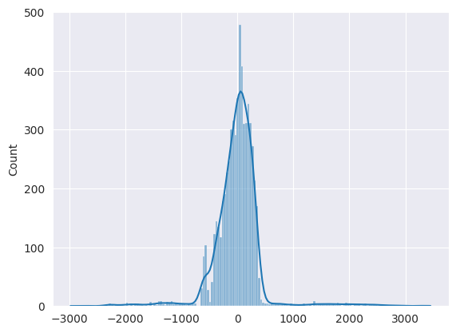

```python
#Plot histogram of residuals

sns.histplot(residual, kde=True)
```

### **3. Linearity of Variables**

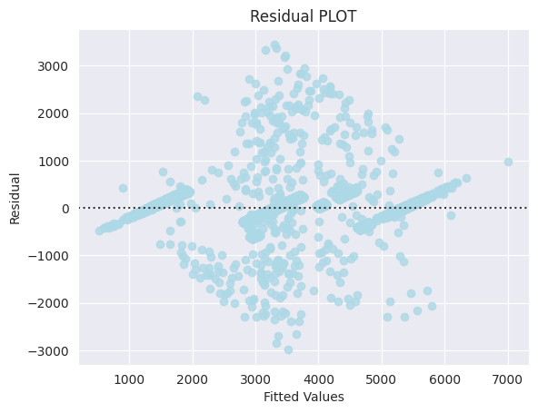

```python
#lets create a plot of the residuals  and fitted values.

fitted = res_3.fittedvalues

sns.residplot(x = fitted, y = residual, color = "lightblue")

plt.xlabel("Fitted Values")

plt.ylabel("Residual")

plt.title("Residual PLOT")

plt.show()
```

### **4. No heteroscedasticity**

We will use Goldfeld–Quandt test to check homoscedasticity.

Null hypothesis : Residuals **are homoscedastic**

Alternate hypothesis : Residuals **are heteroscedastic**

```python
from statsmodels.stats.diagnostic import het_white

from statsmodels.compat import lzip

import statsmodels.stats.api as sms
```

```python
name = ["F statistic", "p-value"]

test = sms.het_goldfeldquandt(y_train, X_train_scaled)

lzip(name, test)
```

```
[('F statistic', np.float64(0.9316481721407387)),
 ('p-value', np.float64(0.9748584502497936))]
```

- p-value is **> 0.05**, so we **fail to Reject H0**.The residuals are **homoscedastic.**

```python
# Applying transform on the test data
X_test_scaled = scaler.transform(X_test)

X_test_scaled = pd.DataFrame(X_test_scaled, index=X_test.index, columns=X_test.columns)

X_test_scaled = sm.add_constant(X_test_scaled)

X_test_scaled = X_test_scaled.drop(['Store_Age', 'Product_Category_Perishables', 'Product_Id_char_FD', 'Product_Allocated_Area'], axis = 1)

X_test_scaled.head()
```

|  | const | Product_Weight | Product_MRP | Product_Sugar_Content_No Sugar | Product_Sugar_Content_Regular | Store_Size_Medium | Store_Size_Small | Store_Location_City_Type_Tier 2 | Store_Location_City_Type_Tier 3 | Store_Type_Food Mart | Store_Type_Supermarket Type1 | Store_Type_Supermarket Type2 | Product_Id_char_NC |
| --- | --- | --- | --- | --- | --- | --- | --- | --- | --- | --- | --- | --- | --- |
| 1226 | 1.0 | 0.473889 | 0.487745 | 0.0 | 1.0 | 1.0 | 0.0 | 1.0 | 0.0 | 0.0 | 0.0 | 1.0 | 0.0 |
| 7903 | 1.0 | 0.516111 | 0.446766 | 0.0 | 0.0 | 1.0 | 0.0 | 1.0 | 0.0 | 0.0 | 0.0 | 1.0 | 0.0 |
| 1559 | 1.0 | 0.332778 | 0.403362 | 0.0 | 1.0 | 0.0 | 0.0 | 1.0 | 0.0 | 0.0 | 1.0 | 0.0 | 0.0 |
| 3621 | 1.0 | 0.373333 | 0.263574 | 1.0 | 0.0 | 0.0 | 1.0 | 0.0 | 1.0 | 1.0 | 0.0 | 0.0 | 1.0 |
| 7552 | 1.0 | 0.644444 | 0.617319 | 0.0 | 0.0 | 0.0 | 0.0 | 1.0 | 0.0 | 0.0 | 1.0 | 0.0 | 0.0 |

```python
X_train_scaled.shape, X_test_scaled.shape
```

```
((6134, 13), (2629, 13))
```

```python
print(res_3.summary())
```

```
                                OLS Regression Results
=====================================================================================
Dep. Variable:     Product_Store_Sales_Total   R-squared:                       0.820
Model:                                   OLS   Adj. R-squared:                  0.820
Method:                        Least Squares   F-statistic:                     3989.
Date:                       Wed, 27 Aug 2025   Prob (F-statistic):               0.00
Time:                               19:59:00   Log-Likelihood:                -46204.
No. Observations:                       6134   AIC:                         9.242e+04
Df Residuals:                           6126   BIC:                         9.248e+04
Df Model:                                  7
Covariance Type:                   nonrobust
===================================================================================================
                                      coef    std err          t      P>|t|      [0.025      0.975]
---------------------------------------------------------------------------------------------------
const                             774.1516     31.835     24.317      0.000     711.743     836.560
Product_Weight                   2491.5805     62.511     39.858      0.000    2369.037    2614.124
Product_MRP                      3018.2040     61.080     49.414      0.000    2898.466    3137.942
Product_Sugar_Content_No Sugar     20.2424      7.958      2.544      0.011       4.643      35.842
Product_Sugar_Content_Regular      34.3279     13.600      2.524      0.012       7.667      60.988
Store_Size_Medium                 689.5868     21.645     31.859      0.000     647.154     732.019
Store_Size_Small                 -277.9468      5.596    -49.665      0.000    -288.918    -266.976
Store_Location_City_Type_Tier 2  -202.7745      8.448    -24.003      0.000    -219.335    -186.214
Store_Location_City_Type_Tier 3  -277.9468      5.596    -49.665      0.000    -288.918    -266.976
Store_Type_Food Mart             -277.9468      5.596    -49.665      0.000    -288.918    -266.976
Store_Type_Supermarket Type1      362.5116     14.738     24.597      0.000     333.619     391.404
Store_Type_Supermarket Type2     -565.2862     16.053    -35.214      0.000    -596.755    -533.817
Product_Id_char_NC                 20.2424      7.958      2.544      0.011       4.643      35.842
==============================================================================
Omnibus:                     1866.015   Durbin-Watson:                   1.994
Prob(Omnibus):                  0.000   Jarque-Bera (JB):            48126.943
Skew:                           0.881   Prob(JB):                         0.00
Kurtosis:                      16.609   Cond. No.                     1.72e+31
==============================================================================

Notes:
[1] Standard Errors assume that the covariance matrix of the errors is correctly specified.
[2] The smallest eigenvalue is 6.5e-59. This might indicate that there are
strong multicollinearity problems or that the design matrix is singular.
```

# **Evaluation Metrics**

```python
print('R-squared:', round(res_3.rsquared, 3))

print('Mean Squared Error:', round(res_3.mse_resid,3))

print('Root Mean Squared Error:', round(np.sqrt(res_3.mse_resid),3))
```

```
R-squared: 0.82
Mean Squared Error: 204522.055
Root Mean Squared Error: 452.241
```

# Observations:

After checking the evaluation metrics on the training partition, we got an MSE (the average squared difference between the estimated values and the actual value) of 204522 and a RMSE of 452.24, which means the model performed good on the predicting the target variable on the training data.

# **Checking cross validation score: Identify underfitted, overfitted or just right fit model.**

```python
# Fitting linear model

from sklearn.linear_model import LinearRegression
from sklearn.model_selection import cross_val_score

linearregression = LinearRegression()

cv_Score11 = cross_val_score(linearregression, X_train_scaled, y_train, cv = 10)

cv_Score12 = cross_val_score(linearregression, X_train_scaled, y_train, cv = 10,
                             scoring = 'neg_mean_squared_error')


print("RSquared: %0.3f (+/- %0.3f)" % (cv_Score11.mean(), cv_Score11.std()*2))

print("Mean Squared Error: %0.3f (+/- %0.3f)" % (-1*cv_Score12.mean(), cv_Score12.std()*2))
```

```
RSquared: 0.819 (+/- 0.050)
Mean Squared Error: 205184.800 (+/- 58115.222)
```

- The R-Squared on the cross-validation is 0.819 which is almost similar to the R-Squared on the training dataset.
- The MSE on cross-validation is 205184 which is almost similar to the MSE on the training dataset.
- It seems like that our model is giving a generalized performance; i.e, not overfitting nor underfitting.

# **Prediction on Test Data and Model Performance**

```python
#Prediction on test data

y_pred = res_3.predict(X_test_scaled)

y_pred
```

|  | 0 |
| --- | --- |
| 1226 | 3382.850732 |
| 7903 | 3330.040800 |
| 1559 | 3014.787023 |
| 3621 | 1706.507387 |
| 7552 | 4402.768977 |
| ... | ... |
| 7864 | 1874.474660 |
| 380 | 4828.570908 |
| 4657 | 3631.937343 |
| 8521 | 5853.553835 |
| 1912 | 4321.643239 |

2629 rows × 1 columns

**dtype:** float64

```python
#Checking evaluation metrics on predictions
from sklearn.metrics import r2_score, mean_absolute_percentage_error, mean_absolute_error, mean_squared_error

mse = mean_squared_error(y_test, y_pred)
rmse = np.sqrt(mse)
mae = mean_absolute_error(y_test, y_pred)
r2 = r2_score(y_test, y_pred)

print("MSE:", mse)
print("RMSE:", rmse)
print("MAE:", mae)
print("R2:", r2)
```

```
MSE: 188364.20009766443
RMSE: 434.0094470143069
MAE: 260.2038217848878
R2: 0.8341275993334893
```

# Observations:

- The model appears to have strong predictive performance, with R-squared around 0.82 on the training partition and 0.83 on the test partition, and RMSE around 450 units.
- The close agreement between training and test metrics indicates that the model generalizes well and is not overfitting or underfitting.

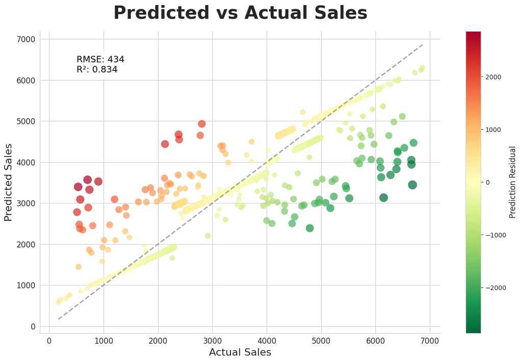

```python
import matplotlib.pyplot as plt
import seaborn as sns
import pandas as pd
import numpy as np

# Prepare data
df = pd.DataFrame({'Actual': y_test, 'Predicted': y_pred})
df['Residual'] = df['Predicted'] - df['Actual']
df['AbsResidual'] = np.abs(df['Residual'])

# Figure and style
plt.figure(figsize=(12, 8))
sns.set_style("whitegrid")
ax = plt.gca()

# Color gradient: green (under) → yellow → red (over)
cmap = plt.cm.RdYlGn_r
norm = plt.Normalize(-df['Residual'].max(), df['Residual'].max())
colors = cmap(norm(df['Residual'].values))

# Scatter points: size proportional to abs(residual)
sizes = 50 + (df['AbsResidual'] / df['AbsResidual'].max() * 150)

# Plot all points at once
scatter = ax.scatter(df['Actual'], df['Predicted'],
                     s=sizes, c=colors, alpha=0.7, edgecolors='none', zorder=3)

# Diagonal line (perfect predictions)
max_val = max(df['Actual'].max(), df['Predicted'].max())
min_val = min(df['Actual'].min(), df['Predicted'].min())
ax.plot([min_val, max_val], [min_val, max_val], linestyle='--', color='gray', lw=2, alpha=0.7, zorder=4)

# Titles and labels
ax.set_title("Predicted vs Actual Sales", fontsize=28, weight='bold', pad=20)
ax.set_xlabel("Actual Sales", fontsize=16)
ax.set_ylabel("Predicted Sales", fontsize=16)

# Annotate metrics
rmse = np.sqrt(np.mean(df['Residual']**2))
r2 = np.corrcoef(df['Actual'], df['Predicted'])[0,1]**2
ax.text(min_val + (max_val-min_val)*0.05, max_val - (max_val-min_val)*0.1,
        f'RMSE: {rmse:.0f}\nR²: {r2:.3f}',
        fontsize=14, weight='medium', color='black',
        bbox=dict(facecolor='white', alpha=0.8, boxstyle='round,pad=0.5'))

# Colorbar
sm = plt.cm.ScalarMappable(cmap=cmap, norm=norm)
sm.set_array(df['Residual'].values)
cbar = plt.colorbar(sm, ax=ax)
cbar.set_label('Prediction Residual', fontsize=12)

# Ticks and spines
ax.tick_params(axis='both', labelsize=12)
sns.despine(ax=ax, left=False, bottom=False)

# Save figure
plt.tight_layout()
plt.savefig("pred_vs_actual_gallery_style_fixed.png", dpi=300)
plt.show()
```

# **Conclusion:**

Our linear regression model achieved strong performance, explaining ~83% of the variation in sales (R² = 0.83) with an RMSE of ~$434. Key drivers of sales include Product MRP and Product Weight, confirming that premium and heavier items generate higher revenue. Medium-sized stores outperform both small and large stores, while Tier 1 city locations consistently achieve stronger sales than Tier 2 or Tier 3. Among store types, Supermarket Type 1 outlets deliver the best results, whereas Food Marts underperform. The close agreement between training and test results indicates that the model generalizes well and is not overfitting.